# r/WallStreetBets Sentiment Analysis in relation to GME

## Introduction

With the stock market becoming more accessible to the average person by the use of Apps like Robinhood, Acorns, WeBull, and more the more we can see the effect of these people having access. With that though is the possibility of having many people banding together with herd mentality with certain public perceptions of certain events. This is what might have happened in the first few months of 2021, where GameStop stock (GME) had defied the expecatations of many hedgefunds and large investors had exploded in value. The large number of social media users that grouped together with these small investment applications caused this rapid increase in GME price, and can be seen in the sentiment of their posts, specifically those that are users of the Reddit page r/WallStreetBets.

## Background

What is thought to happen is that many large investors and hedgefunds did an investment called a short, which in a sense is just a bet that a stock won't do well and making money if the stock prices drastically decreases. However, if the stock price increases the short position actually will cost the the entity shorting the stock money. This is an oversimplified explatnation as I am not a financial expert, and a better explation can be found [here](https://www.investopedia.com/terms/s/shortselling.asp). These large investors had created a pretty massive short position because they thought that GME wasn't going to be doing well due to the nature of the business in combination with the Covid-19 pandemic.

The social media site, Reddit, has a group call r/WallStreetBets that has a bunch of users using those previously mentioned investor applications that use it to communicate on how various aspects of the market works and stocks that they like. One of the stocks that they talk about often and even really like is GME, which could be from nostalgia of using them, that they actually think they are going to be successful, or any other possible number of reasons. They also knew a good amount of the short position that many of those larger investors had taken.

The story out there is that these users banded together and increased the GME price, which the increase of the price caused those large investors to lose large amounts of money when having to close their short positions. This has already had real world effects on the affected investors going forward. However, there are still querstions about those posts and their possible effect of the stock price ,why they had this effect, if it was more out of frustration or anger than another possible sentiment, and if this could likely happen again.

## Exploratory Data Analysis

To begin data has been first collected from [Kaggle](https://www.kaggle.com/gpreda/reddit-wallstreetsbets-posts) and tracking the daily stock information of GME. As well some the required libraries for later analysis.

```python
# Simply setting up the environment and loading the raw data
import pandas as pd
import numpy as np
import nltk
import datetime
from wordcloud import WordCloud,STOPWORDS
from nltk.sentiment.vader import SentimentIntensityAnalyzer

import matplotlib.pyplot as plt
import seaborn as sns
color = sns.color_palette()
%matplotlib inline
import plotly.offline as py
py.init_notebook_mode(connected=True)
import plotly.graph_objs as go
import plotly.tools as tls
import plotly.express as px


# Reddit data
wsb_posts_df = pd.read_csv("reddit_wsb.csv")

# Stock ticker data for GameStop
daily_gme_df = pd.read_csv("GME.csv")

# Quick look at the posts and stock
display(wsb_posts_df.head())
display(daily_gme_df.head())
```

|  | title | score | id | url | comms_num | created | body | timestamp |
| --- | --- | --- | --- | --- | --- | --- | --- | --- |
| 0 | It's not about the money, it's about sending a... | 55 | l6ulcx | https://v.redd.it/6j75regs72e61 | 6 | 1.611863e+09 | NaN | 2021-01-28 21:37:41 |
| 1 | Math Professor Scott Steiner says the numbers ... | 110 | l6uibd | https://v.redd.it/ah50lyny62e61 | 23 | 1.611862e+09 | NaN | 2021-01-28 21:32:10 |
| 2 | Exit the system | 0 | l6uhhn | https://www.reddit.com/r/wallstreetbets/commen... | 47 | 1.611862e+09 | The CEO of NASDAQ pushed to halt trading “to g... | 2021-01-28 21:30:35 |
| 3 | NEW SEC FILING FOR GME! CAN SOMEONE LESS RETAR... | 29 | l6ugk6 | https://sec.report/Document/0001193125-21-019848/ | 74 | 1.611862e+09 | NaN | 2021-01-28 21:28:57 |
| 4 | Not to distract from GME, just thought our AMC... | 71 | l6ufgy | https://i.redd.it/4h2sukb662e61.jpg | 156 | 1.611862e+09 | NaN | 2021-01-28 21:26:56 |

|  | Date | Open | High | Low | Close | Volume |
| --- | --- | --- | --- | --- | --- | --- |
| 0 | 03/17/2021 | 217.84 | 231.47 | 204.00 | 209.81 | 16,481,590 |
| 1 | 03/16/2021 | 203.16 | 220.70 | 172.35 | 208.17 | 35,422,871 |
| 2 | 03/15/2021 | 277.52 | 283.00 | 206.00 | 220.14 | 24,226,189 |
| 3 | 03/12/2021 | 275.00 | 295.50 | 262.27 | 264.50 | 25,845,900 |
| 4 | 03/11/2021 | 241.64 | 281.50 | 232.60 | 260.00 | 28,312,490 |

Seeing this data we can identify some small data cleansing issues that need to be taken care of, such as the timestamps that likely need to be casted in order to properly operate on them and study the sentiment. As well there are some other issues in the titles and body, such as URLs, special characters, differences in captialization, and multiple of spaces. These can be removed fairly easily, which are the first things that we are going to do.

These "clean" versiosn of the strings will be used to do some analysis and look for very common words. The raw versions of it will be used by the a sentiment analysis package in the NLTK VADER module, which uses the puncutation, capitalization, etc. in order to help assign how much sentiment.

|  | title | score | id | url | comms_num | created | body | timestamp | clean_title | clean_body | Date |
| --- | --- | --- | --- | --- | --- | --- | --- | --- | --- | --- | --- |
| 2 | Exit the system | 0 | l6uhhn | https://www.reddit.com/r/wallstreetbets/commen... | 47 | 1.611862e+09 | The CEO of NASDAQ pushed to halt trading “to g... | 2021-01-28 21:30:35 | exit the system | the ceo of nasdaq pushed to halt trading to gi... | 2021-01-28 |
| 6 | SHORT STOCK DOESN'T HAVE AN EXPIRATION DATE | 317 | l6uf6d | https://www.reddit.com/r/wallstreetbets/commen... | 53 | 1.611862e+09 | Hedgefund whales are spreading disinfo saying ... | 2021-01-28 21:26:27 | short stock doesnt have an expiration date | hedgefund whales are spreading disinfo saying ... | 2021-01-28 |
| 7 | THIS IS THE MOMENT | 405 | l6ub9l | https://www.reddit.com/r/wallstreetbets/commen... | 178 | 1.611862e+09 | Life isn't fair. My mother always told me that... | 2021-01-28 21:19:31 | this is the moment | life isnt fair my mother always told me that w... | 2021-01-28 |
| 10 | We need to keep this movement going, we all ca... | 222 | l6uao1 | https://www.reddit.com/r/wallstreetbets/commen... | 70 | 1.611862e+09 | I believe right now is one of those rare oppo... | 2021-01-28 21:18:25 | we need to keep this movement going we all can... | i believe right now is one of those rare oppor... | 2021-01-28 |
| 12 | Once you're done with GME - $AG and $SLV, the ... | 0 | l6u9wu | https://www.reddit.com/r/wallstreetbets/commen... | 16 | 1.611861e+09 | You guys are champs. GME... who would have tho... | 2021-01-28 21:17:10 | once youre done with gme ag and slv the gentle... | you guys are champs gme who would have thought... | 2021-01-28 |

|  | Date | Open | High | Low | Close | Volume |
| --- | --- | --- | --- | --- | --- | --- |
| 0 | 2021-03-17 | 217.84 | 231.47 | 204.00 | 209.81 | 16,481,590 |
| 1 | 2021-03-16 | 203.16 | 220.70 | 172.35 | 208.17 | 35,422,871 |
| 2 | 2021-03-15 | 277.52 | 283.00 | 206.00 | 220.14 | 24,226,189 |
| 3 | 2021-03-12 | 275.00 | 295.50 | 262.27 | 264.50 | 25,845,900 |
| 4 | 2021-03-11 | 241.64 | 281.50 | 232.60 | 260.00 | 28,312,490 |

```
Total number of clean posts 20174
WallStreetBets earliest time 2021-01-28 00:00:00 and latest time 2021-03-15 00:00:00


Total number of GME stock entries 51
GME earliest time collected 2021-01-04 00:00:00 and latest time collected 2021-03-17 00:00:00
Highest GME price 483.0, lowest GME price 17.08
```

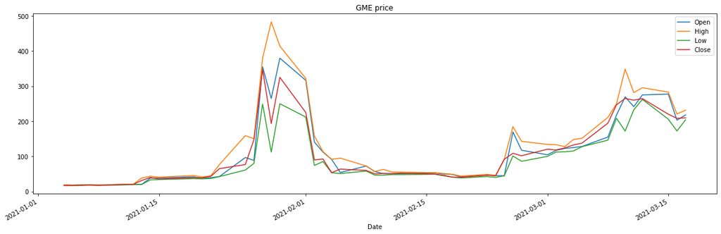

```python
# First going to drop those that have blank bodies since they won't be very helpful for sentiment
# It will also make it easier/smaller to operate on later
wsb_posts_df = wsb_posts_df[ wsb_posts_df.body.notnull() ]
# Removing posts before 2021 since that's before this event
wsb_posts_df = wsb_posts_df[ pd.to_datetime(wsb_posts_df['timestamp']).dt.year>=2021 ]

# Doing string clean ups
wsb_posts_df['clean_title'] = wsb_posts_df['title'].str.lower()
wsb_posts_df['clean_body'] = wsb_posts_df['body'].str.lower()
# Removing URLs
wsb_posts_df['clean_title'] = wsb_posts_df['clean_title'].str.replace(r"http\S+", "", regex=True)
wsb_posts_df['clean_body'] = wsb_posts_df['clean_body'].str.replace(r"http\S+", "", regex=True)
# Removing special characters
wsb_posts_df['clean_title'] = wsb_posts_df['clean_title'].replace(r'[@#$!%^&*()\[\]{}\|\\/,\.:;\'\"?<>“\-_\+=]',
                                                      "", regex=True).str.strip()
wsb_posts_df['clean_body'] = wsb_posts_df['clean_body'].replace(r'[@#$%^&*()\[\]{}\|\\/,\.:;\'\"?<>“\-_\+=]',
                                                    "", regex=True).str.strip()
# Had to add a new operation to remove singular characters
wsb_posts_df['clean_title'] = wsb_posts_df['clean_title'].str.replace(r"\s[a-z]\s", "", regex=True)
wsb_posts_df['clean_body'] = wsb_posts_df['clean_body'].str.replace(r"\s[a-z]\s", "", regex=True)
# Removing multiple spaces
wsb_posts_df['clean_title'] = wsb_posts_df['clean_title'].str.replace(r'\s+', " ", regex=True)
wsb_posts_df['clean_body'] = wsb_posts_df['clean_body'].str.replace(r'\s+', " ", regex=True)

# Fixing the datetime
wsb_posts_df['timestamp']= pd.to_datetime(wsb_posts_df['timestamp'])
wsb_posts_df['Date']= pd.to_datetime(pd.to_datetime(wsb_posts_df['timestamp']).dt.date)

# And similar for the stock data and going to only give the stock data for timeframe we have posts for
daily_gme_df['Date'] = pd.to_datetime(pd.to_datetime(daily_gme_df['Date']).dt.date)

display(wsb_posts_df.head())
display(daily_gme_df.head())

# Going to print some good basic data we might want from it.
print("Total number of clean posts {}".format(wsb_posts_df.shape[0]))
print("WallStreetBets earliest time {} and latest time {}\n\n".format(wsb_posts_df['Date'].min(),
                                                                  wsb_posts_df['Date'].max()))

# Going to show line chart of GME stock price
daily_gme_df.plot(title="GME price", x="Date", figsize=(20,6))
print("Total number of GME stock entries {}".format(daily_gme_df.shape[0]))
print("GME earliest time collected {} and latest time collected {}".format(daily_gme_df['Date'].min(),
                                                                  daily_gme_df['Date'].max()))
print("Highest GME price {}, lowest GME price {}".format(daily_gme_df['High'].max(), daily_gme_df['Low'].min()))
```

After the cleaning of the data has been completed, one of the first things we can do in order to get an understanding of what these posts contain is creating wordclouds for both the title and the body of each of these posts. This gives us a good view of the most common words that are used, which helps us see popular terms and it help catch an initial issue that I had not accounted for. In many of these posts there are rogue singular letters, like 'u' and 's', of which I am not certain is not just a typo. For this reason I had to add another cleaning operation in order to remove singular characters, which even takes out some stopwords like 'I' and 'a' which are just filler that offer no real sentiment.

As well we can see that for the WallStreetBets data there are around 20,000 posts that are in the relevant timeframe after the start of 2021 just before the stock price hike. For the GME stock data collected from [MarketWatch](https://www.marketwatch.com/investing/stock/gme/download-data?startDate=1/1/2021&endDate=3/17/2021) where it is also clear that this stock increase was massive, going from \$17 all to nearly \\$500. This is then followed by a massive drop and a slow clime back uip in the the last few months.

```
(-0.5, 399.5, 199.5, -0.5)
```

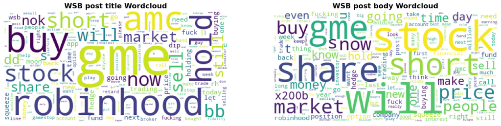

```python
# As a basis going to build a word cloud without the STOPWORDS, but gotta remove the ' characters
new_stopwords = set()
for word in STOPWORDS:
    new_stopwords.add(word.replace("'", ""))

# Creating WordCloud objects
basic_wc_title = WordCloud(stopwords=new_stopwords, background_color='white', collocations = False)\
    .generate(wsb_posts_df[wsb_posts_df['clean_title'].notnull()]['clean_title'].str.cat(sep=" "))
basic_wc_body = WordCloud(stopwords=new_stopwords, background_color='white', collocations = False)\
    .generate(wsb_posts_df['clean_body'].str.cat(sep=" "))

# Creating plots for the wordclouds
f = plt.figure(figsize=(20,6))
ax = f.add_subplot(1,2,1)
ax.set_title('WSB post title Wordcloud',fontsize=16,fontweight='bold')
ax.imshow(basic_wc_title)
plt.axis('off')
plt.subplot(1,2,2)
plt.title('WSB post body Wordcloud',fontsize=16,fontweight='bold')
plt.imshow(basic_wc_body)
plt.axis('off')
```

However, this does mean that there are likely posts that are not directly related to GME which provides two different options.

1. Either remove all all posts from the set that don't directly relate to GME in order to make it a much more targeted analysis but might lose posts that relate to it but don't mention it directly
2. Keep all of the posts for the analysis and possibly have some of the focus taken from GME

Here we will explore the second one, primarily because this is a sentiment analysis and though some posts might be more geared towards other stock that are mentioned like AMC and Nokia's stock it still is a part of the same sentiment behind these choices. GME is the best and most extreme change in stock price and was a favorite for WallStreetBets before this event with how it likely has interacted with the lives of Reddit users.

From here we will begin the process of running the sentiment analysis using VADER (Valence Aware Dictionary and sEntiment Reasoner) which is going to be used on each entry. Each title and body will be given multiple sentiment ratings for the title and body separately, which will then be grouped and analyzed to see the overall effect.

```python
#------------------------------------------------------------------------------
# Function: assignSentiment(p_df, text_cols)
#
# Parameter:
#    In:     text_cols [str...] - List of strings of text columns for
#                                   sentiment analysis
#    Out:    None
#    In/Out: p_df - Dataframe where sentiment scores are to be assigned
#
# Returns:  Dataframe updated with sentiment scores for each desired column
# Desc:     Takes a dataframe and uses the VADER sentiment analysis module
#             with a list of text columns that are to have sentiment scores
#             assigned.
#------------------------------------------------------------------------------
def assignSentiment(p_df, text_cols):
    SIA = SentimentIntensityAnalyzer()
    # Running for each column
    for col in text_cols:
        # First going to assign new columns for each one
        pos_col = "{}_{}".format(col, "pos")
        neu_col = "{}_{}".format(col, "neu")
        neg_col = "{}_{}".format(col, "neg")
        compound_col = "{}_{}".format(col, "comp")
        p_df[pos_col] = p_df[col].apply(lambda x:SIA.polarity_scores(x)['pos'])
        p_df[neu_col] = p_df[col].apply(lambda x:SIA.polarity_scores(x)['neu'])
        p_df[neg_col] = p_df[col].apply(lambda x:SIA.polarity_scores(x)['neg'])
        p_df[compound_col] = p_df[col].apply(lambda x:SIA.polarity_scores(x)['compound'])
    return p_df

# And to run the analysis, and peek a bit into the information
wsb_posts_df = assignSentiment(wsb_posts_df, ['title','body'])
wsb_posts_df.head()
```

|  | title | score | id | url | comms_num | created | body | timestamp | clean_title | clean_body | Date | title_pos | title_neu | title_neg | title_comp | body_pos | body_neu | body_neg | body_comp |
| --- | --- | --- | --- | --- | --- | --- | --- | --- | --- | --- | --- | --- | --- | --- | --- | --- | --- | --- | --- |
| 2 | Exit the system | 0 | l6uhhn | https://www.reddit.com/r/wallstreetbets/commen... | 47 | 1.611862e+09 | The CEO of NASDAQ pushed to halt trading “to g... | 2021-01-28 21:30:35 | exit the system | the ceo of nasdaq pushed to halt trading to gi... | 2021-01-28 | 0.0 | 1.0 | 0.0 | 0.0 | 0.057 | 0.879 | 0.064 | -0.4199 |
| 6 | SHORT STOCK DOESN'T HAVE AN EXPIRATION DATE | 317 | l6uf6d | https://www.reddit.com/r/wallstreetbets/commen... | 53 | 1.611862e+09 | Hedgefund whales are spreading disinfo saying ... | 2021-01-28 21:26:27 | short stock doesnt have an expiration date | hedgefund whales are spreading disinfo saying ... | 2021-01-28 | 0.0 | 1.0 | 0.0 | 0.0 | 0.071 | 0.929 | 0.000 | 0.8663 |
| 7 | THIS IS THE MOMENT | 405 | l6ub9l | https://www.reddit.com/r/wallstreetbets/commen... | 178 | 1.611862e+09 | Life isn't fair. My mother always told me that... | 2021-01-28 21:19:31 | this is the moment | life isnt fair my mother always told me that w... | 2021-01-28 | 0.0 | 1.0 | 0.0 | 0.0 | 0.062 | 0.761 | 0.177 | -0.9942 |
| 10 | We need to keep this movement going, we all ca... | 222 | l6uao1 | https://www.reddit.com/r/wallstreetbets/commen... | 70 | 1.611862e+09 | I believe right now is one of those rare oppo... | 2021-01-28 21:18:25 | we need to keep this movement going we all can... | i believe right now is one of those rare oppor... | 2021-01-28 | 0.0 | 1.0 | 0.0 | 0.0 | 0.155 | 0.764 | 0.082 | 0.8398 |
| 12 | Once you're done with GME - $AG and $SLV, the ... | 0 | l6u9wu | https://www.reddit.com/r/wallstreetbets/commen... | 16 | 1.611861e+09 | You guys are champs. GME... who would have tho... | 2021-01-28 21:17:10 | once youre done with gme ag and slv the gentle... | you guys are champs gme who would have thought... | 2021-01-28 | 0.0 | 1.0 | 0.0 | 0.0 | 0.129 | 0.811 | 0.060 | 0.9632 |

With the high level sentiment analysis for each text object is run, we now can make a few important observations of the sentiment during this time. There is another issue as well, that the sentiment of the title and the body might need to be combined at somepoint, I will weigh the body heavier since many times the title is neutral and in any type of post there is going to be more detail in the body of any post.

First though we might want to take a look at the overall sentiment of the time frame, because this will be the general sentiment of the posts at the time, but as well we can start to look at sentiment of each section alone over time as well.

```
Average Title Text Sentiment: 0.010276197085357392 - Average Body Text Sentiment: 0.16503056904927135
```

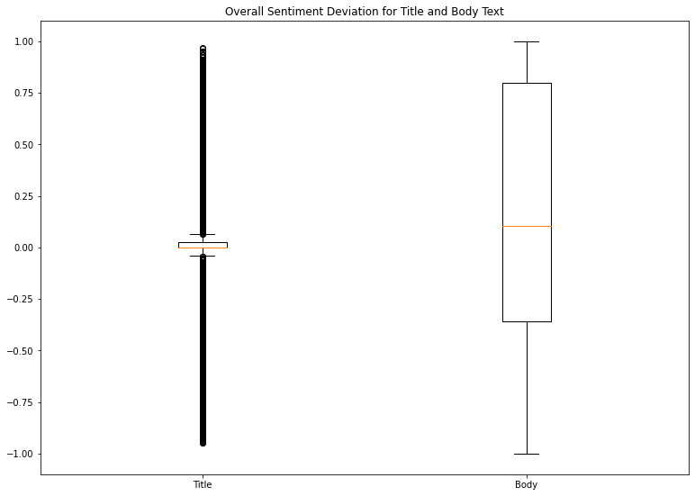

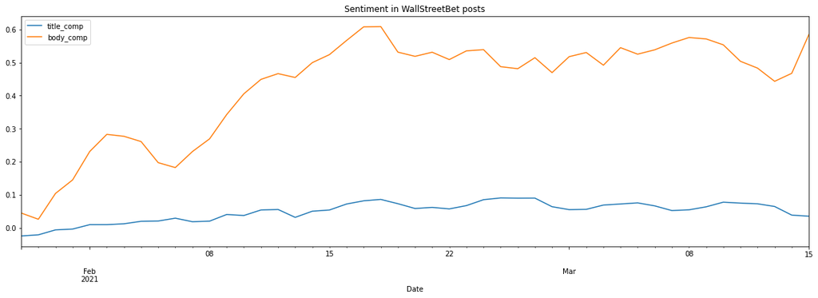

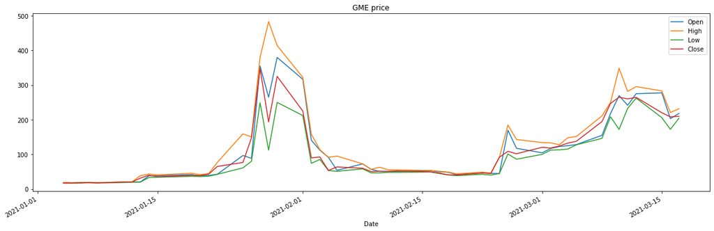

```python
# Building a boxplot with the sentiment analysis
fig = plt.figure(figsize =(10, 7))
ax = fig.add_axes([0, 0, 1, 1])
bp = ax.boxplot([wsb_posts_df['title_comp'].tolist(),wsb_posts_df['body_comp']])
ax.set_xticklabels(['Title', 'Body'])
plt.title("Overall Sentiment Deviation for Title and Body Text")

# And some basic info from it in text
print("Average Title Text Sentiment: {} - Average Body Text Sentiment: {}".format(
    wsb_posts_df['title_comp'].mean(),
    wsb_posts_df['body_comp'].mean()))

# Now going to visualize what going on with sentiment over time
wsb_posts_df[['title_comp','body_comp','Date']].groupby(['Date']).mean().rolling('4D').mean()\
    .plot(title="Sentiment in WallStreetBet posts", figsize=(20,6))
daily_gme_df.plot(title="GME price", x="Date", figsize=(20,6))
```

There are some interesting findings here as well, titles seem to be more nuetral which isn't a surprise but the body text fields of these posts hold typically a more postiive tone according to VADER. You can also see that there is an intersting number of these dates as well that that there are definately spikes in both data, but it can seem a bit difficult to see the full pattern. However, it might first initially be easier to look at the biggest spike in the over in the last week of Janurary adn the first week of February. As well, what might be interesting is seeing the overall amount of activity such as posts, score known as karma on Reddit, and seeing not just the compound sentiment.

The way that I will do it in this case is by weighing the body much heavier than the title, but trying to gurantee some type of score.

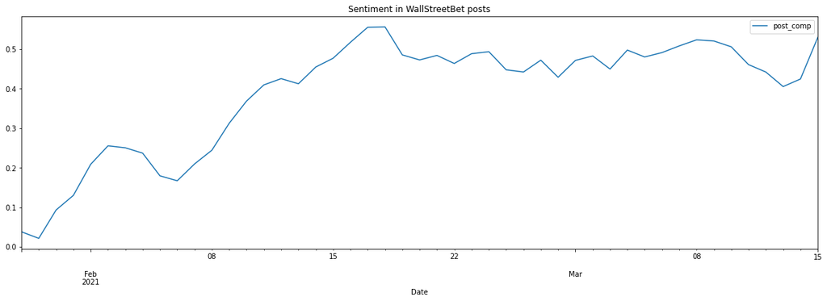

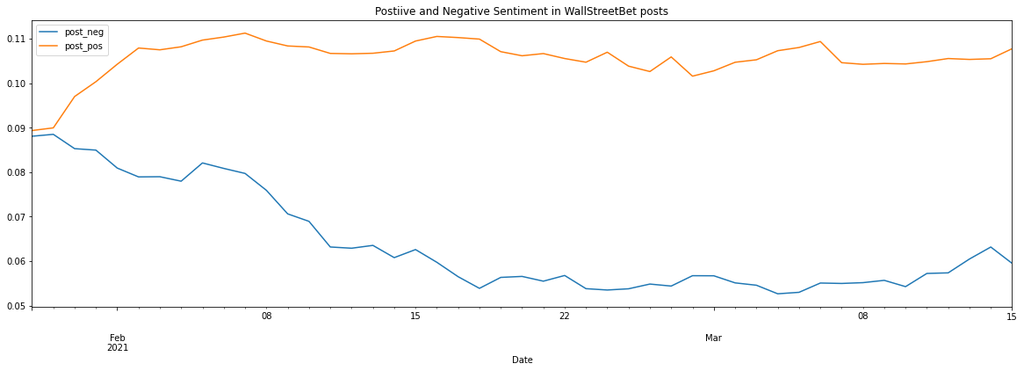

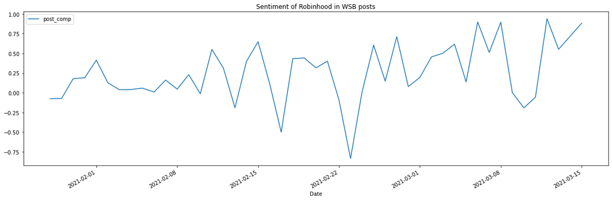

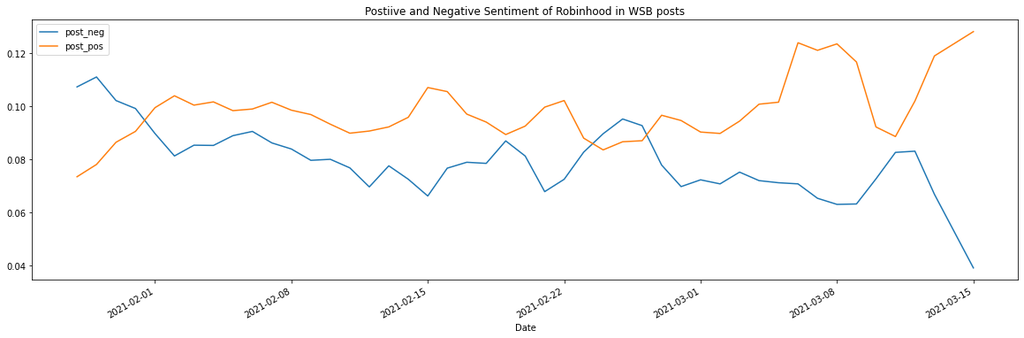

```python
# Going to create a new field using a .1 and .9 weights for title and body text respectively
wsb_posts_df['post_pos'] = (wsb_posts_df['title_pos'] * .1) + (wsb_posts_df['body_pos'] * .9)
wsb_posts_df['post_neu'] = (wsb_posts_df['title_neu'] * .1) + (wsb_posts_df['body_neu'] * .9)
wsb_posts_df['post_neg'] = (wsb_posts_df['title_neg'] * .1) + (wsb_posts_df['body_neg'] * .9)
wsb_posts_df['post_comp'] = (wsb_posts_df['title_comp'] * .1) + (wsb_posts_df['body_comp'] * .9)

wsb_posts_df[['post_comp', 'Date']].groupby(['Date']).mean().rolling('4D').mean()\
    .plot(title="Sentiment in WallStreetBet posts", figsize=(20,6))
wsb_posts_df[['post_neg', 'post_pos','Date']].groupby(['Date']).mean().rolling('4D').mean()\
    .plot(title="Postiive and Negative Sentiment in WallStreetBet posts", figsize=(20,6))

# I am also curious what the opinion of Robbinhood was like at the time
wsb_posts_df[ (wsb_posts_df.clean_title.str.contains('robinhood', regex=True, na=False)) \
             | (wsb_posts_df.clean_body.str.contains('robinhood', regex=True, na=False))
            ][['post_comp','Date']].groupby(['Date']).mean() \
    .plot(title="Sentiment of Robinhood in WSB posts", figsize=(20,6))

wsb_posts_df[ (wsb_posts_df.clean_title.str.contains('robinhood', regex=True, na=False)) \
             | (wsb_posts_df.clean_body.str.contains('robinhood', regex=True, na=False))
            ][['post_neg', 'post_pos','Date']].groupby(['Date']).mean().rolling('4D').mean() \
    .plot(title="Postiive and Negative Sentiment of Robinhood in WSB posts", figsize=(20,6))
```

This will not likely have a massive effect on the graph above in comparisson to the previous visualization, but it does give a better idea of what is a more comprehensive scores since titles are typically shorter and won't have a smuch sentiment. As well the visualization between the compound scores and the raw positive and negative scores needed to be separated because of the scale differences caused the differences in positive and negative values looked so flat.

Now that there is a post total for sentiment I am going to separte them out between positive and negative for a word cloud.

```
(-0.5, 399.5, 199.5, -0.5)
```

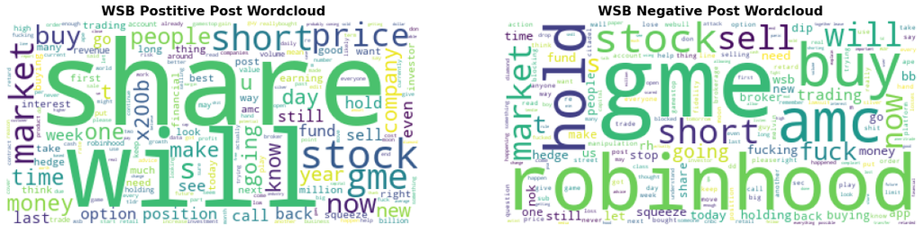

```python
# Creating WordCloud objects
positive_wc = WordCloud(stopwords=new_stopwords, background_color='white', collocations = False)\
    .generate(wsb_posts_df[wsb_posts_df['post_comp'] >= 0.25]['clean_body'].str.cat(sep=" "))
negative_wc = WordCloud(stopwords=new_stopwords, background_color='white', collocations = False)\
    .generate(wsb_posts_df[wsb_posts_df['post_comp'] <= -0.25]['clean_title'].str.cat(sep=" "))

# Creating plots for the wordclouds

f = plt.figure(figsize=(20,6))
ax = f.add_subplot(1,2,1)
ax.set_title('WSB Postitive Post Wordcloud',fontsize=16,fontweight='bold')
ax.imshow(positive_wc)
plt.axis('off')
plt.subplot(1,2,2)
plt.title('WSB Negative Post Wordcloud',fontsize=16,fontweight='bold')
plt.imshow(negative_wc)
plt.axis('off')
```

However, another thing that is going to be helpful is taking a look at some metadata that is availabe in the posts, like score, number of comments, and number of posts per day. This can give a good idea at the general level of engagement and possibly the reception of certain posts. In combination if the data is good enough some of these engagement measures can be used to magnify their sentiment.

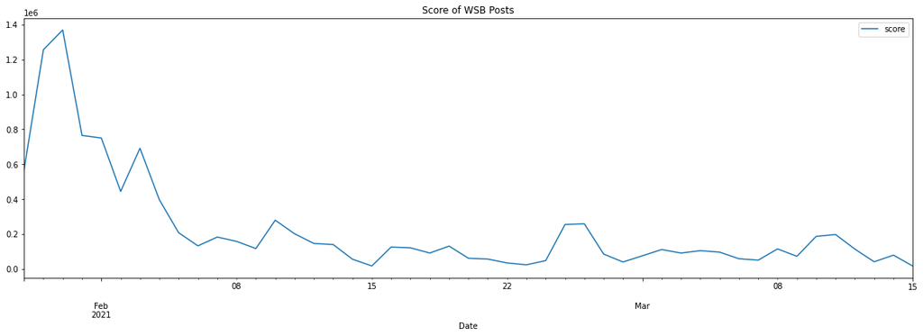

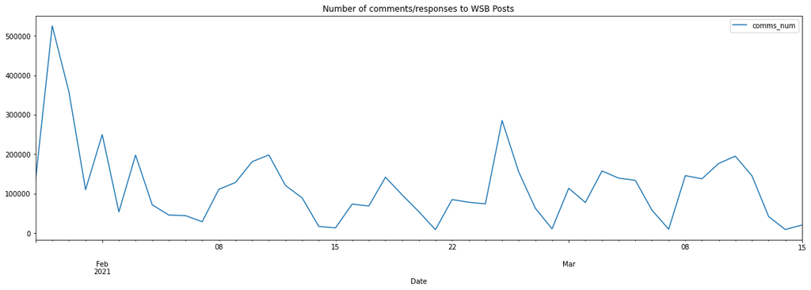

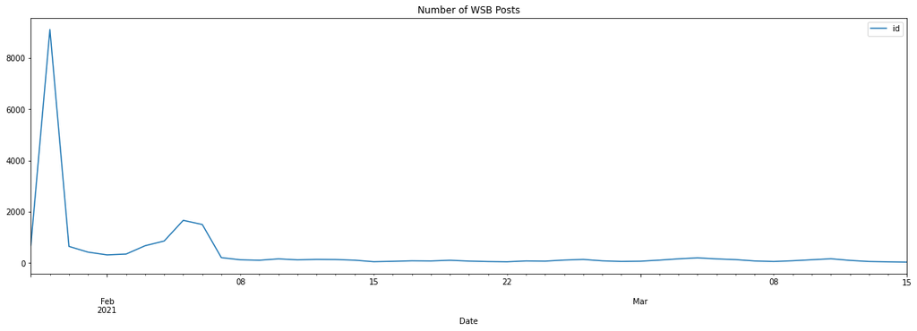

```python
# Going to take a look at some of these different metadata items
wsb_posts_df[['score','Date']].groupby(['Date']).sum()\
    .plot(title="Score of WSB Posts", figsize=(20,6))

wsb_posts_df[['comms_num','Date']].groupby(['Date']).sum()\
    .plot(title="Number of comments/responses to WSB Posts", figsize=(20,6))

wsb_posts_df[['id','Date']].groupby(['Date']).count()\
    .plot(title="Number of WSB Posts", figsize=(20,6))
```

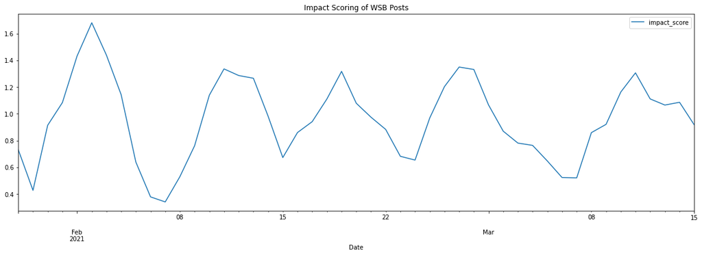

```python
# The score is going to have the a full amount of weight, but comments will be slightly reduced because
# it cannot take into account the sentiment of the responses themselves
wsb_posts_df['impact_score'] = ((wsb_posts_df['score']) + (wsb_posts_df['comms_num']/10))

# Then we are going to put this on a different scale from 1 to 100 in order to not throw off the scaling
# sentiment entirely. Have to use min-max normalization to avoid negative numbers
wsb_posts_df['impact_score'] = ( (wsb_posts_df['impact_score']-wsb_posts_df['impact_score'].min()) \
                                / ( wsb_posts_df['impact_score'].max() - wsb_posts_df['impact_score'].min() ) \
                               ) * 100

wsb_posts_df[['impact_score','Date']].groupby(['Date']).mean().rolling('4D').mean()\
    .plot(title="Impact Scoring of WSB Posts", figsize=(20,6))
```

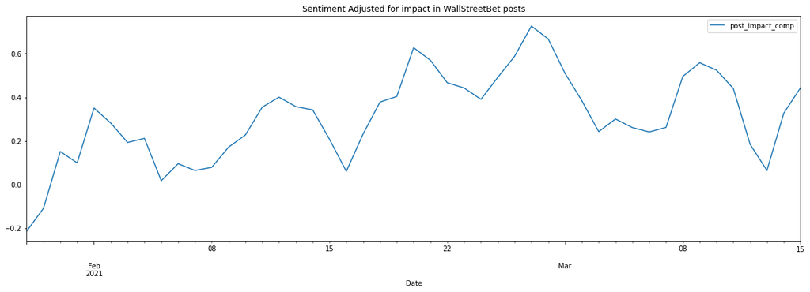

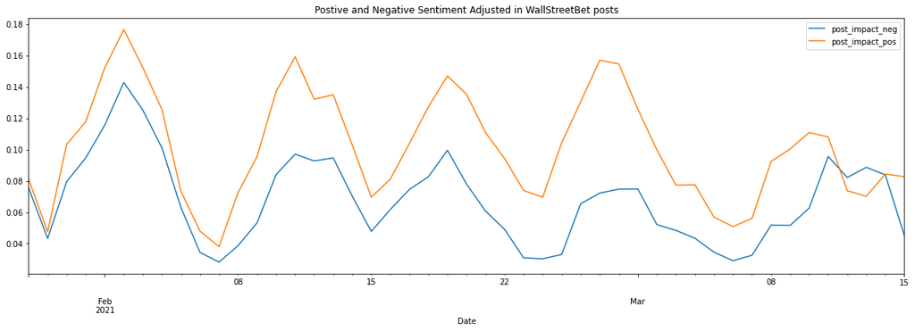

```python
# Using the impact score as a multiplier
wsb_posts_df['post_impact_pos'] = wsb_posts_df['post_pos'] * wsb_posts_df['impact_score']
wsb_posts_df['post_impact_neu'] = wsb_posts_df['post_neu'] * wsb_posts_df['impact_score']
wsb_posts_df['post_impact_neg'] = wsb_posts_df['post_neg'] * wsb_posts_df['impact_score']
wsb_posts_df['post_impact_comp'] = wsb_posts_df['post_comp'] * wsb_posts_df['impact_score']

# Then visualizing the new adjust sentiment
wsb_posts_df[['post_impact_comp', 'Date']].groupby(['Date']).mean().rolling('4D').mean()\
    .plot(title="Sentiment Adjusted for impact in WallStreetBet posts", figsize=(20,6))
wsb_posts_df[['post_impact_neg', 'post_impact_pos','Date']].groupby(['Date']).mean().rolling('4D').mean()\
    .plot(title="Postive and Negative Sentiment Adjusted in WallStreetBet posts", figsize=(20,6))
```

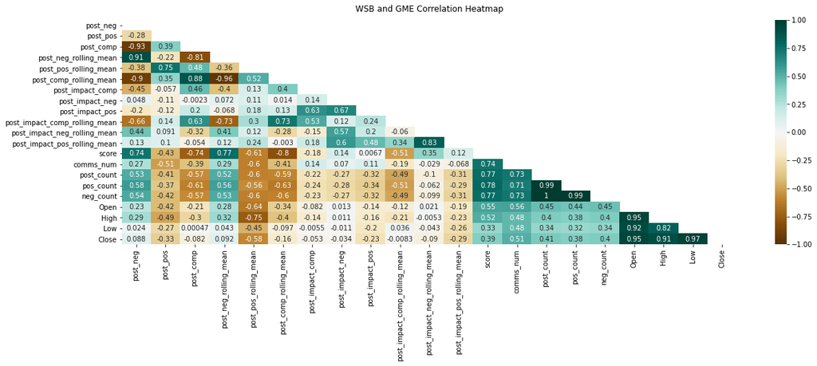

```python
# Now going to run a join on multiple aggergations using the Date field

# Starting with the normal post data without weights
merged_df = pd.merge(
    wsb_posts_df[['post_neg', 'post_pos', 'post_comp','Date']].groupby(['Date']).mean(),
    wsb_posts_df[['post_neg', 'post_pos', 'post_comp','Date']].groupby(['Date']).mean()\
    .rolling('4D').mean().rename(columns={
        'post_pos':'post_pos_rolling_mean',
        'post_neg':'post_neg_rolling_mean',
        'post_comp':'post_comp_rolling_mean'
    }),
    left_index=True,
    right_index=True
)

# Adding means of the adjusted scores
merged_df = pd.merge(
    merged_df,
    wsb_posts_df[['post_impact_comp', 'post_impact_neg', 'post_impact_pos','Date']].groupby(['Date']).mean(),
    left_index=True,
    right_index=True
)

# Now the rolling averages for this one
merged_df = pd.merge(
    merged_df,
    wsb_posts_df[['post_impact_comp', 'post_impact_neg', 'post_impact_pos','Date']].groupby(['Date']).mean()\
    .rolling('4D').mean().rename(columns={
        'post_impact_comp':'post_impact_comp_rolling_mean',
        'post_impact_neg':'post_impact_neg_rolling_mean',
        'post_impact_pos':'post_impact_pos_rolling_mean'
    }),
    left_index=True,
    right_index=True
)

# Now a few other data points such as counts and raw impact numbers
merged_df = pd.merge(
    merged_df,
    wsb_posts_df[['score','Date']].groupby(['Date']).sum(),
    left_index=True,
    right_index=True

)
merged_df = pd.merge(
    merged_df,
    wsb_posts_df[['comms_num','Date']].groupby(['Date']).sum(),
    left_index=True,
    right_index=True

)
merged_df = pd.merge(
    merged_df,
    wsb_posts_df[['id','Date']].groupby(['Date']).count().rename(columns={
        'id':'post_count'
    }),
    left_index=True,
    right_index=True

)
merged_df = pd.merge(
    merged_df,
    wsb_posts_df[wsb_posts_df['post_comp'] >= 0.25][['id','Date']].groupby(['Date']).count().rename(columns={
        'id':'pos_count'
    }),
    left_index=True,
    right_index=True

)
merged_df = pd.merge(
    merged_df,
    wsb_posts_df[wsb_posts_df['post_comp'] <= -0.25][['id','Date']].groupby(['Date']).count().rename(columns={
        'id':'neg_count'
    }),
    left_index=True,
    right_index=True

)


# And finally merging with the GME data
merged_df = pd.merge(
    merged_df,
    daily_gme_df.set_index('Date'),
    left_index=True,
    right_index=True

)

# Going to create a heat map to show the correlations between these datapoints
plt.figure(figsize=(20,6))
mask = np.triu(np.ones_like(merged_df.corr(), dtype=np.bool))

heatmap = sns.heatmap(merged_df.corr(), mask=mask, vmin=-1, vmax=1, annot=True, cmap='BrBG')
heatmap.set_title('WSB and GME Correlation Heatmap', fontdict={'fontsize':12}, pad=12);
```

One of the more interesting findings is that the there were positive correlations between GME pricing data and the various pieces of metadata from the posts themselves. This does make some sense, that sense more interactions that users had with the posts the more likely they would buy GME stock. The count of postive and negative posts seems to have some positive correlation.